# Modelling of Ecosystem-Atmosphere Processes - Photosynthesis and Stomatal Conductance

The same behavior applies to the relative change in stomatal conductance when Vcmax is modified. The model is more sensitive to a decrease than to an increase in Vcmax. (Figure 2.3)

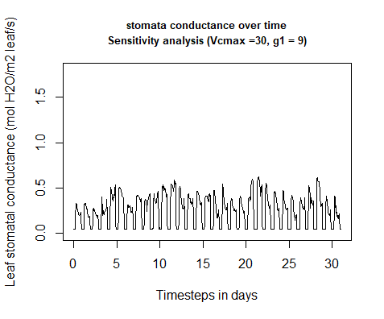

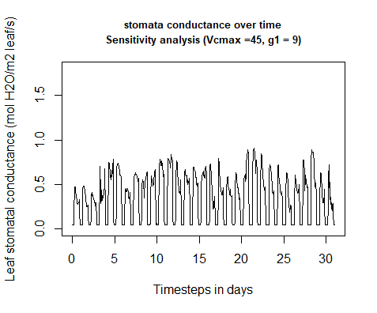

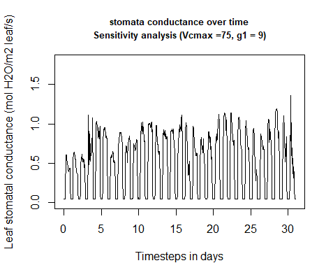

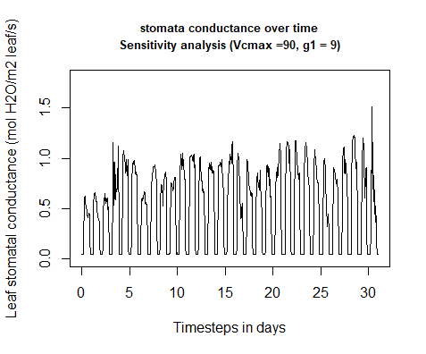

**Figure 2.3: Stomata conductance response to sensitivity analysis (Vcmax modification)**

The model responds to increasing Vcmax with a shift of the photosynthesis temperature optimum. The temperature optimum increases about 7 K from -50% Vcmax to +50% Vcmax. (Figure 2.4)

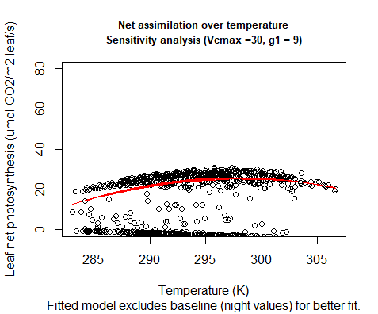

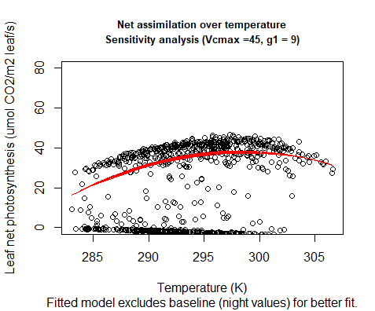

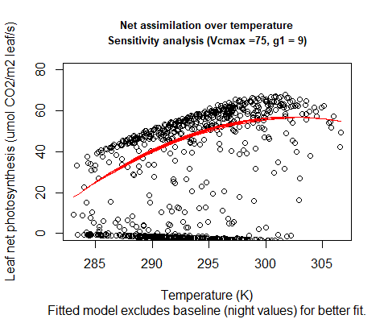

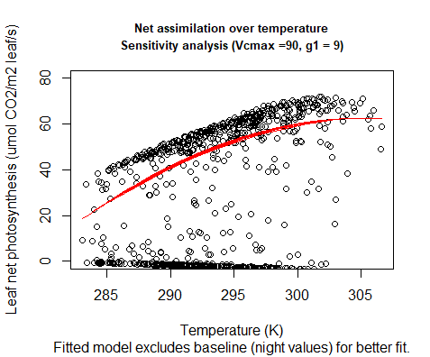

**Figure 2.4: Temperature response to sensitivity analysis (Vcmax modification)**

#### g1 modification

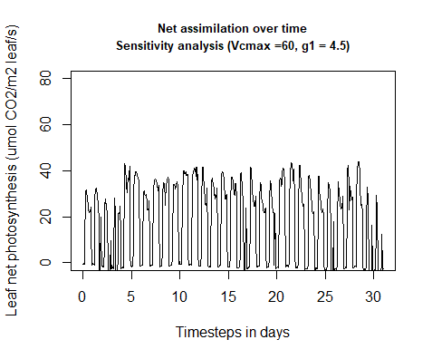

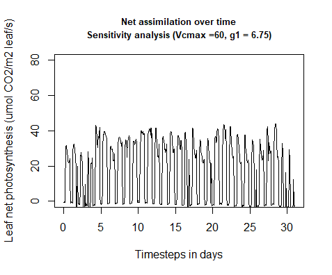

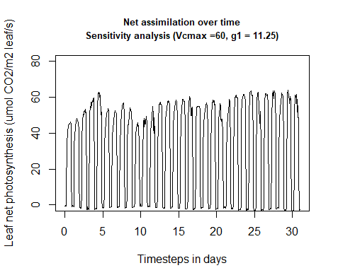

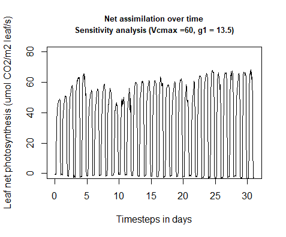

**Figure 2.5: Net assimilation response to sensitivity analysis (g1 modification)**

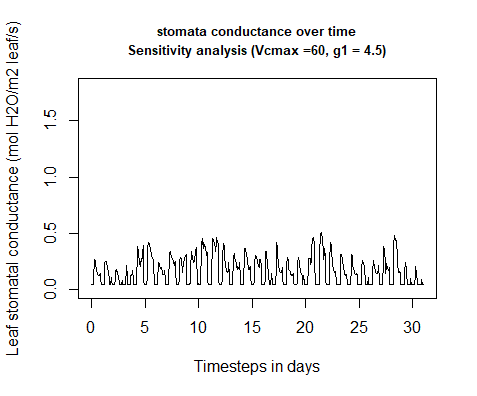

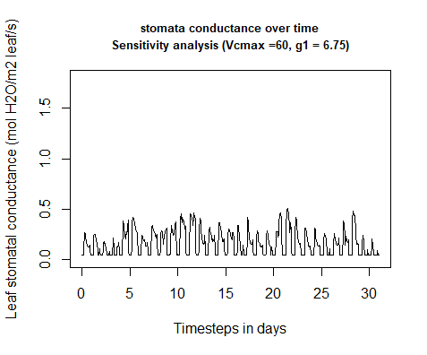

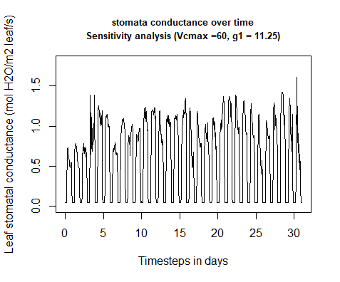

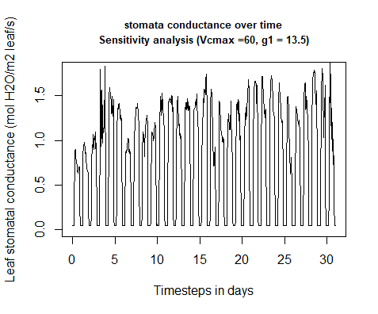

**Figure 2.6: Stomata conductance response to sensitivity analysis (g1 modification)**

Net assimilation responds to temperature under g1 modification with a shift in temperature optimum relative to increasing g1. The temperature optima of the different g1 scenarios coves a slightly larger range than the optima of the Vcmax modification. (Figure 2.7 & 2.4)

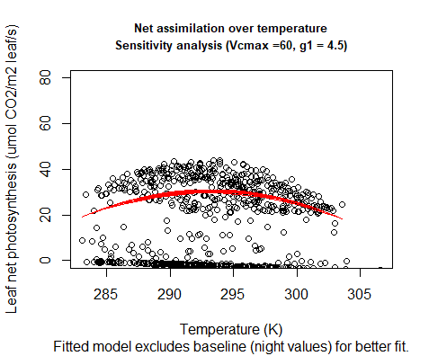

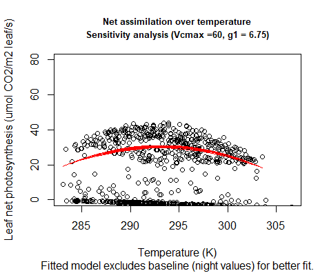

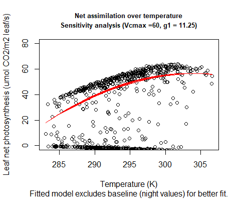

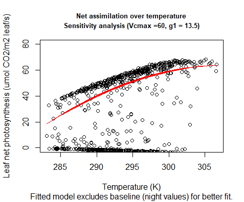

**Figure 2.7: Temperature response to sensitivity analysis (g1 modification)**

### Modeled vs. observed data

#### Comparison

To compare modeled and observed data, the model was run over one year with 2018 climate data from the Hainich Forest. The first obvious difference is that the modeled photosynthesis is much higher than the observed data with a maximum value of 62.2 umol CO2/m2 leaf/s while observed GPP peaks at 40.6 umol CO2/m2 leaf/s. Furthermore the modeled photosynthesis commences after roughly 100 days with no respiration before Day 100 and after Day 300. Observed GPP increases and decreases around similar times of the year but shows activity in winter as well. (Figure 3.1)

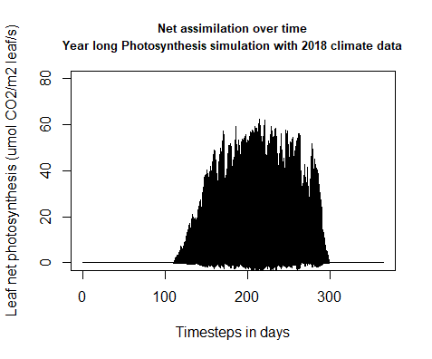

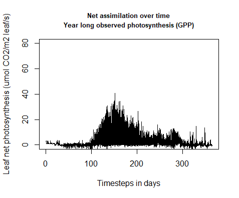

**Figure 3.1: Modeled photosynthesis vs. observed photosynthesis**

#### Stomatal conductance

Modeled stomatal conductance shows a similar trend as modeled photosynthesis with no activity until ~ Day 100 and stp of activity at Day 300. (Figure 3.2)

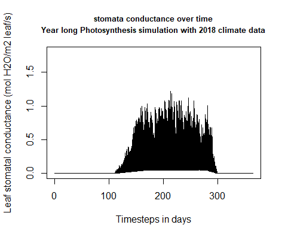

**Figure 3.2: Modeled stomatal conductance over one year**

#### Temperature response

The temperature optimum of modeled photosynthesis lies at approximately 300 K (~27° C) (Figure 3.3)

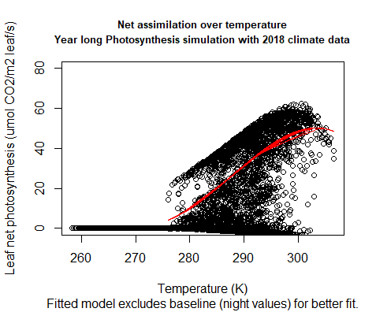

**Figure 3.3: Temperature dependence of modeled photosynthesis**

## Discussion

### Calibration

### Sensitivity analysis

The sensitivity analysises show a general trend of the model being more sensitive if Vcmax and g1 are decreased compared to when they are increased. This may be due to the limiting effect that Vcmax has on the model with carboxylation being arguably a strongly limiting factor of photosynthesis, the model is harshly regulated by a decrease. If Vcmax is increased, the model may be limited by different factors, which cause the net assimilation to not reach the full potential of Vcmax. Limiting factors could be light, water potential or nutritive supply (which is not considered in this model). The temperature response of net assimilation to increasing Vcmax can be explained by the lower activation energy for carboxylation if temperature is increased further (Benomar et al., 2019). This interaction can be understood by the temperature dependence of the entropy term in the peaked arrhenius function (Theory, Equation 1.11 & 1.12).

### Modeled vs. Observed

When comparing modeled and observed data, the photosynthesis for the most part of the year is perfectly zero. Due to missing foiliage, a missing assimilation is quite possible, however zero activity for net assimilation is not realistic since respiration is not accounted for. Therefor, during winter, a negative net assimilation would be more plausible. After inspecting the input climate data for missing or implausible values, it is clear that the problem does not lie within that input data. It therefor can be either a potential error in the radiation input or an erroneous condition in the model which causes net assimilation to be completely zero. Regarding the strong difference in the amplitude of the model compared to the observed assimilation, we can refer to the difficulties in the calibration process which would lower Vcmax and g1 to unrealisticly low values. If realistic values were applied, unrealistic results were given. We suspect a problem within the model, concerning an overexaggerated conversion factor or an error in the use of the leaf area index.

### Problems during transcription

### Conclusion

It can be concluded that the model in its current state lacks the necessary realism when compared to actual field data. Various efforts have been made during the course to either modify the code, acquire different data or understand the data structure in terms of units, interactions and conversions. However, despite the model actually returning an output, quite some work remains until the results may be appplied in a professional environment. Nevertheless, building the model, debugging and merging the code with other groups has resulted in an intensive involvement with the topic and provided a qualitative learning experience about ecosystem modelling as a team effort.

## References

## Appendix

### Plotmaker making of

To have a uniform and simple way of producing plots, we designed a plotmaker function which allowed us to feed in the output data of the model. The plotmaker then ran a few linear and nonlinear models to better understand the trend of the data. Since nighttime values create a baseline of subzero values, we decided to exclude these values from the regressions to avoid a distortion of the model.

```r
#### Linear models ####

d.mod = data.frame(out, Sitedata) #creating a linear model data frame

d.mod.norm.an = subset(d.mod[which(d.mod$an > 0),])#only taking values >0
d.mod.norm.an$tair2 = d.mod.norm.an$tair^2
qmtemp_an = lm(d.mod.norm.an$an ~ d.mod.norm.an$tair + d.mod.norm.an$tair2 )

d.mod.norm.gs = subset(d.mod[which(d.mod$gs > 0.1),])#only taking values >0.1
d.mod.norm.gs$tair2 = d.mod.norm.gs$tair^2
qmtemp_gs = lm(d.mod.norm.gs$gs ~ d.mod.norm.gs$tair + d.mod.norm.gs$tair2 )

qmsw_an = nls(out$an~a*Sitedata$sw_in/(1+b*Sitedata$sw_in),data=c(out, Sitedata),start=list(a=1.8,b=0.04))

temp_an_predict = predict(qmtemp_an)
temp_gs_predict = predict(qmtemp_gs)
sw_in_an_predict = predict(qmsw_an)
```

**Then the pdf is rendered by running different plot function consecutively and combining them into one file.**

```r
S = "Subtitle"
pdf (file= "Filepath")

plot(out$an ~ c(1:length(out$an)), xlab = "Timesteps in 30 min", ylab = "Leaf net photosynthesis (umol CO2/m2 leaf/s)", main= c("Net assimilation over time", S), type = "l", cex.main= 0.8, ylim = c(0,80))
plot(out$gs ~ c(1:length(out$an)), xlab = "Timesteps in 30 min", ylab = "Leaf stomatal conductance (mol H2O/m2 leaf/s)", main= c("stomata conductance over time", S), type = "l", cex.main= 0.8, ylim =c(0,1.8))

plot(out$an ~ Sitedata$tair, xlab = "Temperature (K)", ylab = "Leaf net photosynthesis (umol CO2/m2 leaf/s)", main = c("Net assimilation over temperature", S), sub = "Fitted model excludes baseline (night values) for better fit.", cex.main= 0.8, ylim = c(0,80))
lines(temp_an_predict ~ d.mod.norm.an$tair, col = "red")

plot(out$gs ~ Sitedata$tair, xlab = "Temperature (K)", ylab = "Leaf stomatal conductance (mol H2O/m2 leaf/s)", main =c("stomata conductance over temperature", S), sub = "Fitted model excludes baseline (night values) for better fit.", cex.main= 0.8, ylim = c(0, 1.8))
lines(temp_gs_predict ~ d.mod.norm.gs$tair, col = "red")

plot(out$an ~ Sitedata$sw_in, xlab = "Incoming shortwave radiation (W/m2)", ylab ="Leaf net photosynthesis (umol CO2/m2 leaf/s)", main = c("Net assimilation over shortwave radiation", S), cex.main= 0.8, ylim = c(0,80))
lines(sw_in_an_predict ~ Sitedata$sw_in, col="red")
dev.off()
```